# Practical Implementations of Principal Component Analysis

Nick Belgau, Oscar Hernandez Mata

2024-08-01

## Principal Component Analysis (PCA)

- Normalized to have pixel values between 0 and 1.
- Training, validation, and test sets were created.

```python
import tensorflow as tf
from sklearn.model_selection import train_test_split
from sklearn.decomposition import PCA

# Loading the training and test sets
(X_train, y_train), (X_test, y_test) = tf.keras.datasets.cifar10.load_data()

# Normalize the pixel values to range 0-1
X_train = X_train.astype('float32') / 255
X_test = X_test.astype('float32') / 255

# Split the training set to create a validation set
X_train, X_validate, y_train, y_validate = train_test_split(
    X_train, y_train, test_size=0.15, random_state=42)

# Flatten the X data
X_train_flat = X_train.reshape((X_train.shape[0], -1))
X_validate_flat = X_validate.reshape((X_validate.shape[0], -1))
X_test_flat = X_test.reshape((X_test.shape[0], -1))

# Initialize PCA and fit on the training data
pca = PCA(n_components=0.95)
pca.fit(X_train_flat)

# Transform both the training and testing data
X_train_pca = pca.transform(X_train_flat)
X_validate_pca = pca.transform(X_validate_flat)
X_test_pca = pca.transform(X_test_flat)
```

- After flattening, PCA was applied to retain 95% of the explained variance.

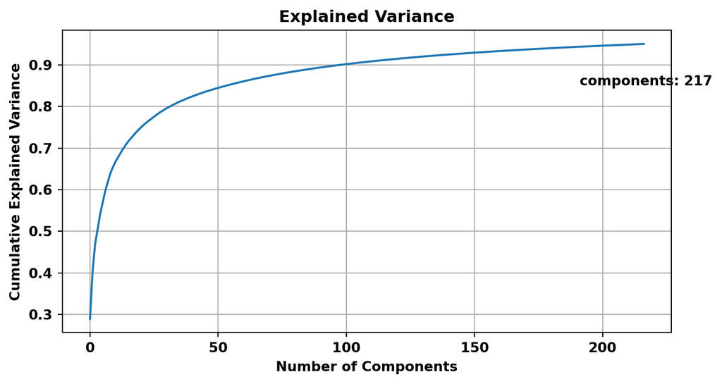

## Modeling: Support Vector Machine (SVM)

- Traditionally, SVM used for image classification (rbf, nonlinear kernel).
- Compared SVM to SVM with PCA-reduced data.
- PCA model achieved similar accuracy but 10x faster prediction time.

```
          Model  Accuracy  Prediction Time (s), n=100
0           SVM     0.536                       14.14
1  SVM with PCA     0.533                        1.40
```

- This demonstrates the effectiveness of dimensionality reduction in speeding up predictions without compromising accuracy.

## Modeling: Convolutional Neural Network

- About
- Architecture
- Training Results
- Recognize situations where PCA may not be the optimal choice.
- CNNs have become the gold-standard for for image classification tasks.
- PCA is typically not used before a CNN because it destroys the spatial complexity by flattening the data.

(Goel, Goel, and Kumar 2023)

- 9-layer CNN, Conv2D layers, ‘softmax’ for multi-class probs.
- Model architecture addresses overfitting by using Dropout and MaxPooling2D.

```python
model_cnn = Sequential([
    Input(shape=(32, 32, 3)),
    Conv2D(32, 3, padding='valid', activation='relu'),
    MaxPooling2D(pool_size=(2, 2)),
    Dropout(0.25),
    Conv2D(64, 3, activation='relu'),
    MaxPooling2D(pool_size=(2, 2)),
    Dropout(0.25),
    Conv2D(128, 3, activation='relu'),
    Flatten(),
    Dense(64, activation='relu'),
    Dropout(0.50),
    Dense(10, activation='softmax'),
])
```

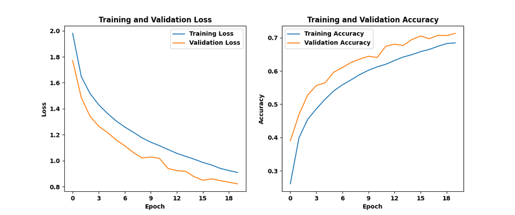

## Model Evaluation

```
          Model  Accuracy  Prediction Time (s), n=100  Model Size (MB)
0           SVM     0.536                       14.14            894.7
1  SVM with PCA     0.533                        1.40             65.2
2           CNN     0.705                        0.16              2.6
3           CNN     0.736                        0.18             10.1
```

- These qualities make CNNs a great choice for real-time image classification, deployed directly on IoT devices without prior dimensionality reduction.

## Conclusion

- PCA simplifies data through dimensionality reductions by transforming original variables into uncorrelated principal components.
- Benefits: captures patterns, addresses multicollinearity and overfitting, and enhances computational efficiency and model performance.
- Challenges: Sensitive to outliers and may lose important information in nonlinear relationships.
- Application #1 - Reduced the dimensions of tabular data and how it grouped features from demographic US census data into buckets like health and environmental factors.
- Application #2 - Image compression and identified when PCA may not be the best technique.
- PCA is really helpful tool to have in your toolbox because it can be used in a wide range of ML applications and throughout the EDA process.

Goel, Akash, Amit Kumar Goel, and Adesh Kumar. 2023. “The Role of Artificial Neural Network and Machine Learning in Utilizing Spatial Information.” *Spatial Information Research* 31: 275–85. https://doi.org/10.1007/s41324-022-00494-x.